# 9 Liikennerikokset

*Mika Sutela*

## 9.2 Johdanto

Tässä liikennerikoksia käsittelevässä luvussa tarkastellaan liikennerikollisuuden yleistä kehitystä sekä erikseen törkeiden liikenneturvallisuuden vaarantamisrikosten ja rattijuopumusrikosten osalta. Päihteet ja ajonopeudet kuuluvat poliisin liikennevalvonnan ja liikenneturvallisuustyön keskeisiin vaikuttavuuskohteisiin, mutta myös nuoret ovat tärkeä poliisin liikenneturvallisuustyön kohde (Poliisi 2022). Päihteiden vaikutuksen alaiset ajoneuvojen kuljettajat ovat uhka muille tienkäyttäjille ja he myös usein itse kärsivät päihteidenkäytön muista haitallisista seurauksista.

Liikennerikosten osalta tärkeimmät tietolähteet ovat Tilastokeskuksen ylläpitämä rikos- ja pakkokeinotilasto, joka sisältää tietoja poliisin, Tullin ja rajavartiolaitoksen tietoon tulleista rikoksista sekä epäillyistä tekijöistä ja uhreista. Tilasto kuvastaa siis viranomaisten tietoon tulleita rikoksia ja on siten yhteydessä viranomaisten harjoittamaan valvontaan. Katsauksessa keskitytään tarkastelemaan lähtökohtaisesti rikoslain (jälj. RL) 23 luvun (545/1999) mukaisia liikennerikoksia. Eräistä liikennerikkomuksista seuraa 1.6.2020 voimaan tulleen tieliikennelain (729/2018) myötä sakkomääräyksen sijaan hallinnollisena seuraamuksena liikennevirhemaksu, mikä vaikuttaa nykyisin huomattavasti liikennerikkomusten määrään tilastoissa.

## 9.3 Liikennerikollisuuden kehitys

Vuonna 2024 liikennerikoksia kirjattiin 118 276 kappaletta. Laskua vuoteen 2023 verrattuna oli 1,1 prosenttia. Liikennerikokset muodostivat vuonna 2024 lähes neljänneksen (23 %) kaikista rikoslakirikoksista. Liikennerikoksista lähes puolet (45 %) liittyi ylinopeudella ajamiseen (Poliisi 2025b).

Poliisin tietoon tulleiden liikennerikosten määrä on vahvasti yhteydessä poliisin suorittamaan liikennevalvontaan. Poliisi käytti liikennevalvontaan viime vuonna 423,9 henkilötyövuotta (HTV), mikä oli 2,6 prosenttia enemmän kuin vuonna 2023. Ilman automaattista liikennevalvontaa vastaava luku vuonna 2024 oli 372,2 (2023: 364,7). Vuonna 2024 automaattivalvonnan osuus oli noin 12 prosenttia kaikesta liikennevalvontaan käytetystä resurssista. (Poliisi 2025b.)

*Törkeät liikenteen vaarantamisrikokset*

Suomen pääteillä keskinopeus kesällä 2024 oli 93,9 km/h, ja talvella 2024-2025 hieman alhaisempi 87,2 km/h. Keskinopeus pysyi jotakuinkin samana kuin edellisenä vuonna niin kesällä kuin myös talvella. Pääteillä ajavista autoista tien nopeusrajoituksen ylitti kesällä 44 prosenttia ja talvella 53 prosenttia. Yli 10 km/h ylinopeutta ajoi kesällä 10 prosenttia ja talvella 13 prosenttia autoista. Tiedot perustuvat Fintrafficin LAM-pisteisiin. (Traficom 2025.)

Liikenneturvallisuuden vaarantamisen törkeän tekomuodon eli törkeän liikenneturvallisuuden vaarantamisen (RL 23:2) tunnusmerkistön täyttää useimmiten moottorikäyttöisen ajoneuvon tai raitiovaunun kuljettaminen nopeudella, joka ylittää huomattavasti sallitun enimmäisnopeuden. Käytännössä rajana pidetään noin 50 km/h vallitsevan nopeusrajoituksen ylitystä. Rikosten määrä on viime vuosina ollut aiempaa korkeammalla tasolla, mutta on kuitenkin vähentynyt vuoden 2020 huippulukemista. Vuonna 2024 viranomaisten tietoon tuli 4 858 törkeää liikenneturvallisuuden vaarantamista, mikä oli 0,7 prosenttia vähemmän kuin vuonna 2023 (kuvio 1).

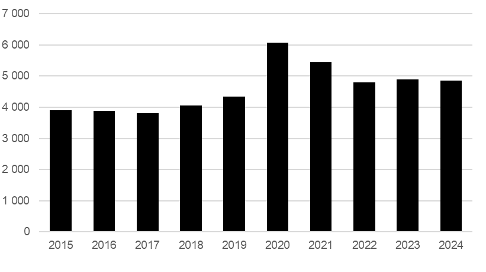

Sisältö kerrottu edeltävässä tekstiosuudessa.

**Kuvio 1** Viranomaisten tietoon tulleet törkeät liikenneturvallisuuden vaarantamiset vuosina 2015–2024. *Lähde*: Tilastokeskus 2024a.

Rattijuopumusrikokset

Säännökset rattijuopumuksesta, sen törkeästä tekomuodosta, vesi-, ilma- ja junaliikennejuopumuksesta sisältyvät RL 23 lukuun. Moottoriajoneuvon tai raitiovaunun kuljettaja tuomitaan rattijuopumuksesta, jos hänen verensä alkoholipitoisuus ajon aikana tai sen jälkeen on vähintään 0,5 promillea tai että hänellä tällöin on vähintään 0,22 milligrammaa alkoholia litrassa uloshengitysilmaa. Rattijuopumuksesta tuomitaan myös silloin, jos kuljettajan veressään on ajon aikana tai sen jälkeen huumausaineen vaikuttavaa ainetta tai sen aineenvaihduntatuotetta. Törkeän rattijuopumuksen osalta vaaditaan lisäksi, että kuljettajan kyky tehtävän vaatimiin suorituksiin on tuntuvasti heikentynyt ja olosuhteet ovat sellaiset, että rikos on omiaan aiheuttamaan vaaraa toisen turvallisuudelle. Kulkuneuvon luovuttaminen juopuneelle (RL 23:8) ja liikennejuopumus moottorittomalla ajoneuvolla (RL 23:9) ovat myös rangaistavia.

Vuonna 2024 rattijuopumusrikoksia (RL 23:3–4) kirjattiin 14 472 kappaletta, mikä oli 9,1 prosenttia vähemmän kuin edellisenä vuonna (kuvio 2). Rattijuopumusrikosten määrä on jatkanut jo edeltävinä vuosina havaittua vähenevää kehityskulkua. Viranomaisten kirjaamista rattijuopumusrikoksista törkeiden rattijuopumusten osuus väheni tasaisesti vuosina 2015–2020, mutta on sen jälkeen jälleen hieman kasvanut ollen vuonna 2024 noin 39 prosenttia.

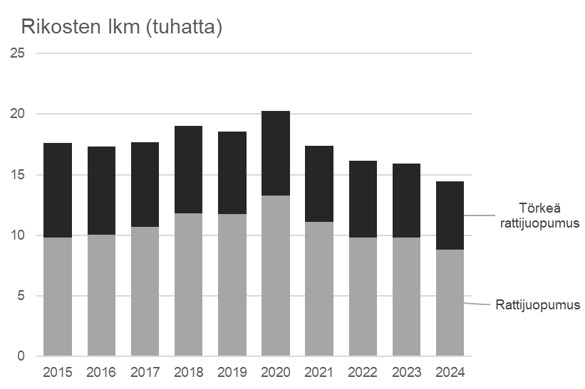

Sisältö kerrottu edeltävässä tekstiosuudessa.

**Kuvio 2** Viranomaisten tietoon tulleet rattijuopumusrikokset vuosina 2015–2024.  
*Lähde:* Tilastokeskus 2025a.

Vuodesta 2003 alkaen poliisi on kirjannut rattijuopumustapauksista erikseen alkoholi- ja huumetapaukset sekä tapaukset, joissa nämä molemmat (sekakäyttötapaukset) ovat rattijuopumuksen perusteena. Vuonna 2024 alkoholitapausten osuus kaikista rattijuopumusrikoksista oli noin 59 prosenttia. Rattijuopumusrikollisuuden määrään vaikuttavat muun muassa päihteiden kulutus ja käyttötavat väestössä.

Vuonna 2024 huumetapauksien osuus perusmuotoisissa rattijuopumuksissa oli 54 prosenttia, alkoholitapauksia oli 40 prosenttia ja sekakäyttötapauksia 7 prosenttia (kuvio 3a). Vastaavasti törkeissä rattijuopumuksissa alkoholitapausten osuus oli 89 prosenttia, huumetapauksia oli 3 prosenttia ja sekakäyttötapauksia 8 prosenttia (kuvio 3b)**.** Perusmuotoisissa rattijuopumuksissa huumetapausten osuus on vähentynyt vuoden 2020 jälkeen 14 prosenttiyksikköä. Törkeissä rattijuopumuksissa alkoholitapauksia on yhä yhdeksän kymmenestä, vaikka alkoholin ja huumausaineiden sekakäyttötapausten osuus on viime vuosina lisääntynyt.

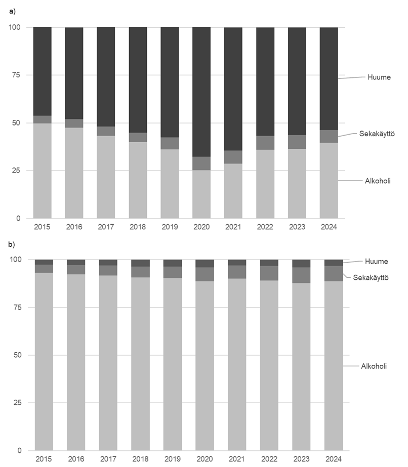

Sisältö kerrottu edeltävässä tekstiosuudessa.

**Kuvio 3** Tilastoitujen a) rattijuopumusten ja b) törkeiden rattijuopumusten alkoholi-, huume- ja sekakäyttötapausten prosenttiosuudet vuosina 2015–2024. *Lähde:* Tilastokeskus 2025a.

Keskusrikospoliisin (2025) tilastojen perusteella rikosteknisen laboratorion huumaus- ja lääkeainetutkimuksissa huumerattijuopumuksesta epäillyn verestä löytyi keskimäärin kolmea eri huumaus- tai lääkeainetta. Yleisin verinäytteissä todettu yksittäinen huumausaine oli amfetamiini, mutta tapausten määrä jäi kuitenkin vuonna 2024 aiempia vuosia alhaisemmalle tasolle. Yleisimmin todetut lääkeaineet kuuluivat bentsodiatsepiinien ryhmään. Tähän ryhmään kuuluvia aineita todettiin yhteensä 6 193 kpl. Myös bentsodiatsepiinien määrä oli alhaisempi kuin aiempina vuosina.

## 9.4 Nuoret liikennerikoksista epäiltyinä

Valtaosa nuorista pyrkii käyttäytymään liikenteessä turvallisesti ja välttämään turhaa riskinottoa, mutta joukkoon mahtuu myös riskikuljettajia. Nuoria riskikuljettajia on eri tutkimusten mukaan arvioitu olevan 10–17 prosenttia kaikista nuorista. Riskialttiille ajotavalle ovat ominaista esimerkiksi liikennesäännöistä piittaamattomuus, ajaminen humalassa ja ilman turvavyötä. Nuoren kuljettajan onnettomuusriski kasvaa usein silloin, kun kuljettajalla on kyydissä kavereita. Tällöin myös halu näyttää ja tarve kilpailla lisäävät riskejä.

Liikennerikollisuus painottuu nuoruuteen ja liikenneonnettomuuksissa nuoret ovat yliedustettuina. Vuonna 2024 tilastoitiin noin 23 100 eri liikennerikoksesta epäiltyä nuorta 15–24-vuotiasta henkilöä, kun huomioon otetaan vuoden sisällä kaikkein "vakavin rikos" (kuvio 4). Miesten osuus näistä nuorista henkilöistä oli 83 prosenttia.

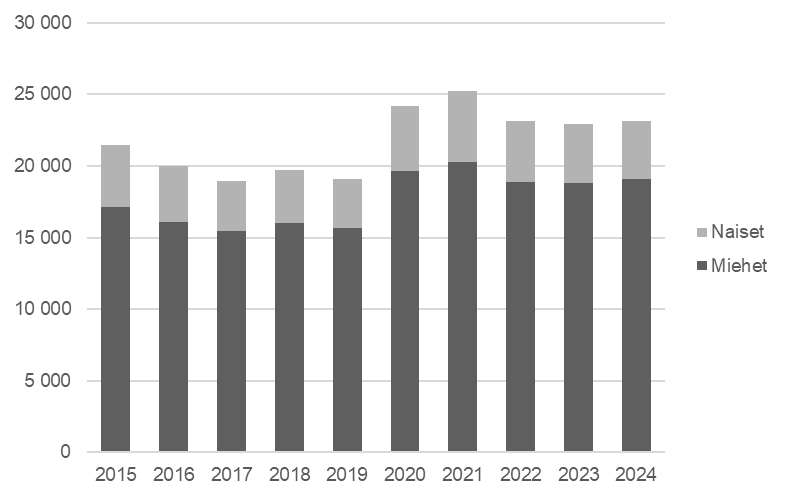

Sisältö kerrottu edeltävässä tekstiosuudessa.

**Kuvio 4** Liikennerikoksista epäillyt nuoret (15–24-v.) henkilöt sukupuolen mukaan vuosina 2015–2024. *Lähde*: Poliisi 2024.

Analysoitaessa rikosepäilyjen määrää, jolloin samakin henkilö voi olla rikoksesta epäiltynä tilastossa useampaankin kertaan yhden vuoden aikana, vuonna 2024 kaikista liikennerikosepäilyistä nuorten osuus oli noin 31 prosenttia. Törkeissä liikenneturvallisuuden vaarantamisissa vastaava luku oli noin 49 prosenttia.

Liikennerikosepäilyt miesten ja naisten osalta suhteessa 100 000 väestöryhmään kuuluvaa kohti on hyvin eriytynyttä. Miehillä liikennerikosepäilyjä oli vuonna 2024 niin nuorilla kuin 25 vuotta täyttäneillä noin 4–5-kertaisesti naisiin verrattuna (kuvio 5).

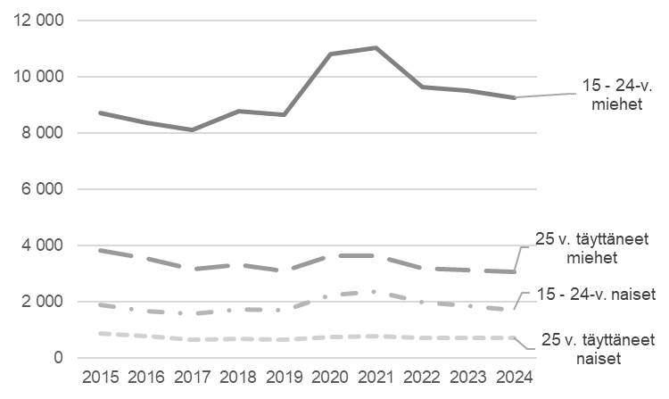

Sisältö kerrottu edeltävässä tekstiosuudessa.

## 9.5 Liikennevirhemaksuun johtaneet rikkomukset

**Taulukko 1** Tieliikennelain vastaiset liikennerikkomukset vuonna 2024. *Lähde*: Poliisi 2025b.

| **Liikennerikkomus** | N |
| --- | --- |
| Moottorikäyttöisen ajoneuvon kuljettaja ylitti liikenteenohjauslaitteella osoitetun suurimman sallitun nopeuden 1–10 kilometrillä tunnissa alueella, jonka nopeusrajoitus on 20–60 km/h | 64 491 |
| Moottorikäyttöisen ajoneuvon kuljettaja ylitti liikenteenohjauslaitteella osoitetun suurimman sallitun nopeuden 11–15 kilometrillä tunnissa alueella, jonka nopeusrajoitus on 20–60 km/h | 27 713 |
| Moottorikäyttöisen ajoneuvon kuljettaja ylitti liikenteenohjauslaitteella osoitetun suurimman sallitun nopeuden 1–10 kilometrillä tunnissa alueella, jonka nopeusrajoitus on 70–120 km/h | 18 396 |
| Moottorikäyttöisen ajoneuvon kuljettaja ylitti liikenteenohjauslaitteella osoitetun suurimman sallitun nopeuden 16–20 kilometrillä tunnissa alueella, jonka nopeusrajoitus on 20–60 km/h | 15 775 |
| Moottorikäyttöisen ajoneuvon kuljettaja ylitti liikenteenohjauslaitteella osoitetun suurimman sallitun nopeuden 11–15 kilometrillä tunnissa alueella, jonka nopeusrajoitus on 70–120 km/h | 9 453 |
| Moottorikäyttöisen ajoneuvon kuljettaja ylitti liikenteenohjauslaitteella osoitetun suurimman sallitun nopeuden 16–20 kilometrillä tunnissa alueella, jonka nopeusrajoitus on 70–120 km/h | 7 360 |
| Moottorikäyttöisen ajoneuvon kuljettaja käytti viestintävälinettä ajon aikana siten, että piti sitä kädessään | 6 712 |
| Ajoneuvon kuljettaja ei käyttänyt ajon aikana turvavyötä | 3 583 |
| Moottorikäyttöisen ajoneuvon kuljettajana ei noudattanut pakollinen pysäyttäminen -liikennemerkkiä | 2 422 |
| Moottorikäyttöisen ajoneuvon kuljettaja ei noudattanut kiinteää punaista liikennevaloa | 2 047 |
| Moottorikäyttöisen ajoneuvon kuljettajana ei noudattanut moottorikäyttöisellä ajoneuvolla ajo kielletty -liikennemerkkiä | 1 662 |
| Muut liikennerikkomukset yhteensä | 8 436 |
| **Kaikki liikennerikkomukset yhteensä** | **168 050** |

Muita liikennerikkomuksia olivat esimerkiksi erilaiset ajoneuvolain (82/2021) vastaiset ajoneuvolakirikkomukset (N = 9 597; 5,4 %) ja vesiliikennelain (782/2019) vastaiset vesiliikennerikkomukset (N = 688; 0,4 %). Ajoneuvolakirikkomuksiin lukeutuvat tyypillisimpinä rikkomuksina esimerkiksi se, jos moottorikäyttöisen ajoneuvon kuljettajana käyttää liikenteessä joko ajoneuvoa, joka on määräaikaiskatsastamattomuuden vuoksi käyttökiellossa tai jos liikenteessä käyttää ajoneuvoa, joka on kunnoltaan, rakenteeltaan tai varusteiltaan määräysten vastainen. Vesiliikennerikkomuksiin sisältyy esimerkiksi se, että vesiliikennemerkillä osoitettua nopeusrajoitusta ei ole noudatettu tai että vesikulkuneuvon päällikkö ei ole huolehtinut, että vesikulkuneuvossa on käsisammutin.

## 9.6 Lähteet

Fintraffic.2024. Ajonopeudet maanteillä 2023, julkaistu 10.6.2024. https://www.fintraffic.fi/fi/uutiset/ajonopeudet-maanteilla-2023-raportti-nopeudet-paateilla-edellisvuosien-tasolla

Keskusrikospoliisi. 2024. Liikennejuopumustilastot 2023. Rikostekninen laboratorio 19.3.2024. Vantaa: Keskusrikospoliisi. https://poliisi.fi/-/liikennejuopumustilastot-2023-huumausainerattijuopumuksia-eniten-nuorten-aikuisten-ikaryhmassa

Liikenneturva. 2022. Nuoret liikenteessä. https://www.liikenneturva.fi/liikenteessa/nuoret-liikenteessa/

Poliisi. 2022. Poliisin liikennevalvonnan ja -turvallisuuden toiminta- ja kehittämissuunnitelma 2022–2030. Poliisihallituksen julkaisusarja 1/2022. Espoo: Poliisihallitus. https://poliisi.fi/julkaisut/-/asset_publisher/Ga8MkKWl5ss3/content/poliisin-liikennevalvonnan-ja-turvallisuuden-toiminta-ja-kehittamissuunnitelma-2022-2030?_com_liferay_asset_publisher_web_portlet_AssetPublisherPortlet_INSTANCE_Ga8MkKWl5ss3_assetEntryId=126364310

Poliisi. 2024. Tulostietojärjestelmä PolStat.

Tilastokeskus. 2024a. Rikos- ja pakkokeinotilasto. Helsinki: Tilastokeskus. https://www.stat.fi/til/rpk/index.html

Tilastokeskus. 2024b. Väestörakenne. Helsinki: Tilastokeskus. http://www.stat.fi/til/vaerak/index.html

# 10 Rikollisuuden piirteitä